# Estimating Distribution Functions

CEA

Author

John Graves

Published

November 21, 2023

# Introduction

This posting runs through various approaches for estimating distribution functions, and functions of distribution functions such as expected values.

Let’s start with some definitions. First, define random variable $X$. The **cumulative distribution function** (CDF) of $X$ is the probability that $X$ takes on some value less than $x$:

$$\begin{eqnarray}
F_X(s) = P(X \leq x)
\end{eqnarray}
\tag{1}$$

The **probability density function** (PDF) tells us about the relative likelihood that $X$ takes on any given value, and can be defined as the derivative of the CDF:

$$f_X(x) = \frac{dF_X(x)}{dx}
\tag{2}$$

Working in the opposite direction, we can also define the CDF by integrating the PDF:

$$F_X(x)=\int_{-\infty}^x f_X(t) d t
\tag{3}$$

This relationship is helpful because it allows us to define the **expected value** of $X$ as a weighted sum of values $x$, with weights defined by the PDF. In integral notation:

$$\mathrm{E_X}[X]=\int_{-\infty}^{\infty} x f_X(x) dx
\tag{4}$$

## Description of Data

Our example data will be taken from the Oregon Health Insurance Experiment (OHIE). We’ll focus on the experimental or “reduced form” aspect of the OHIE by comparing individuals randomized to Medicaid eligibility to those randomized to control. Our primary outcome of interest will be hemoglobin A1C levels.

```r
library(tidyverse)
library(qte)
library(here)
library(glue)
library(conflicted)
library(hrbrthemes)
library(broom)
library(edfun)
library(scam)
library(quantregForest)
conflict_prefer("filter","dplyr")
select <- dplyr::select
options("scipen" = 100, "digits" = 5)
ggplot2::theme_set(hrbrthemes::theme_ipsum(grid = "X"))

df <- haven::read_dta(here("_ignore/CS9-Oregon-Insurance-Experiment-RCT-IV-Data.dta")) %>%
 mutate(D =  treatment) %>%
 mutate(Y = a1c_inp) %>%
 select(Y,D,nnnnumhh_li_2 ,nnnnumhh_li_3 ,age_inp, bp_sar_inp, female, starts_with("age_decile_dum"),weight_total_inp) %>%
 na.omit()
```

# Estimating CDFs

R provides functionality for estimating empirical CDFs directly (using hte command `ecdf()`). However, it is useful to understand how this function works, because this basic intuition will carry through other approaches to estimating CDFs and conditional CDFs below.

Essentially, to construct an empirical CDF for a given variable $X$, we define various values $t$ by traversing over the “support” or range of $X$ and create a series of binary indicators for whether the value of $X$ is less than or equal to $t$. Typically, these $t$ values are defined by splitting up the support of $X$ into evenly spaced values.

More formally,

$$F_n(t)=\#\left\{x_i \leq t\right\} / n=\frac{1}{n} \sum_{i=1}^n \mathbf{1}_{\left[x_i \leq t\right]} .$$
With these values in hand, we can construct a plot of $t$ (x-axis) and the CDF values (y-axis). In R we obtain these CDF values using `ecdf()`:

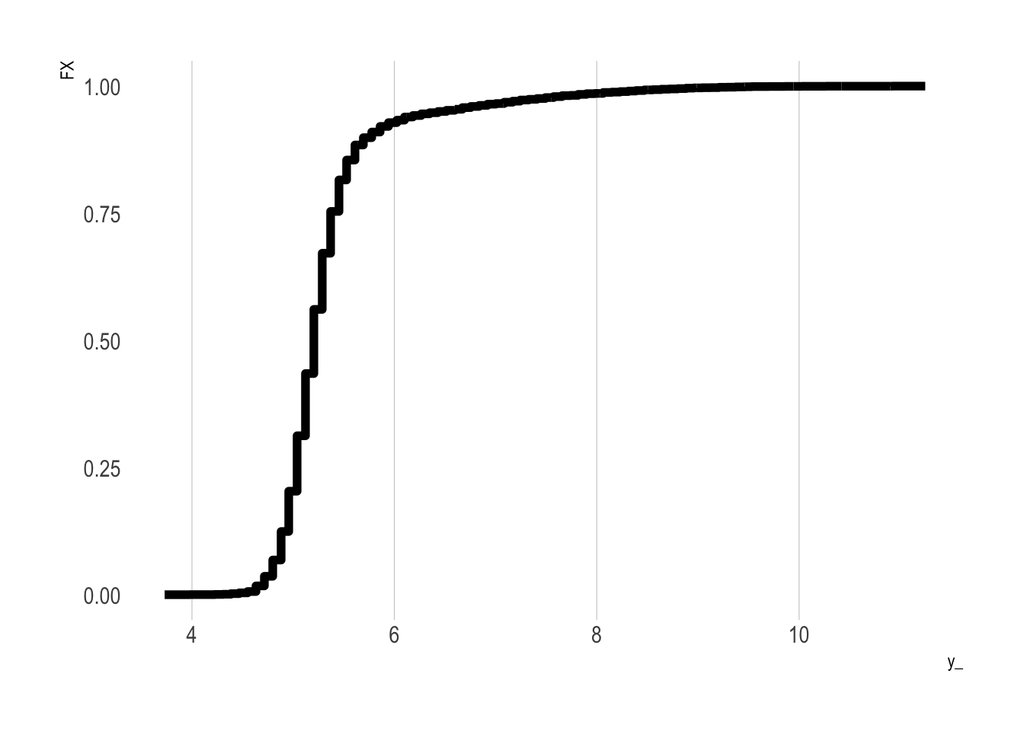

## Do It “By Hand” Using Regression

In the example below, we’ll construct a CDF “by hand” by defining our various values of $t$ (which we’ll call `y_`), and then looping over them. Within each loop, we first define a binary outcome, with values of one if the value of $Y$ is less than or equal to the given `y_` value under consideration, and zero otherwise. We next regress this binary outcome on an intercept only; the resulting coefficient on the intercept term provides an estimate of the fraction of the sample with a $Y$ value less than or equal to the `y_` value.

We repeat this for all `y_` values and plot the result *as a yellow line* on top of the previous plot:

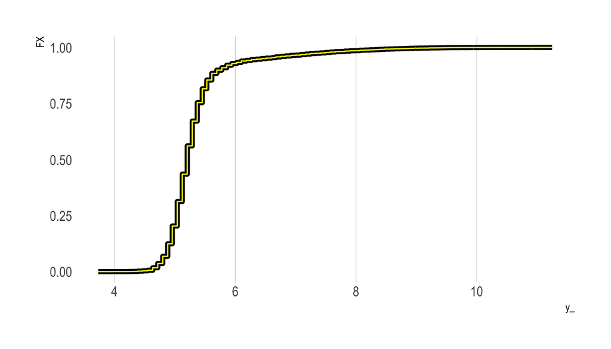

Empirical CDF

As the figure shows, we have successfully replicated the empirical CDF plot produced by `ecdf()`.

## Do It “By Hand” Using Logistic Regression

We’ll next repeat the above exercise, but only change the regression type. That is, rather than fit a linear probability model using `lm()`, we’ll fit a logistic regression model. We then need to predict the outcome response to obtain an estimate of the fraction of the sample with value less than or equal to the given `y_` value (this is analogous to obtaining the coefficient on the intercept term in the linear probability model approach above).

Our new eCDF values are plotted in red below. As the plot shows, we obtain essentially the same eCDF curve:

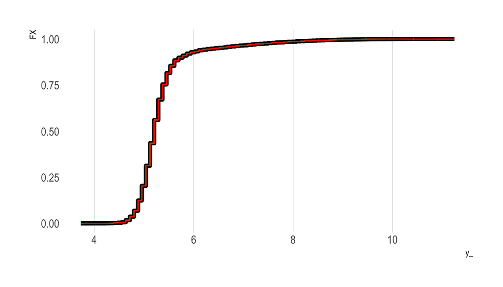

Empirical CDF

## Create A “Smoothed” Version Using a Shape-Constrained Generalized Additive Model

Recall from above that to calculate the PDF of $X$ we can differentiate the CDF (Equation 2). However, the eCDFs calculated above are “chunky”—they are essentially step functions that move at discrete values defined over the support of the outcome.

Depending on the application we may want to fit a smoothed function to these step function values. While R provides functionality to fit a smoothed curve to a given set of points (`approxfun()`), the resulting approximation function will likely not play by the rules of a CDF (e.g., minimum value 0, maximum value 1, monotonically increasing throughout, etc.).

To fit this approximation function we can fit a **shape constrained additive model** that imposes these constraints. In the plot below, this new smoothed eCDF curve is plotted in green over the step function plotted above.

This approach is based on the paper [here](https://link.springer.com/article/10.1007/s11222-013-9448-7) and the code [here](https://stackoverflow.com/questions/51438627/get-the-derivative-of-an-ecdf).

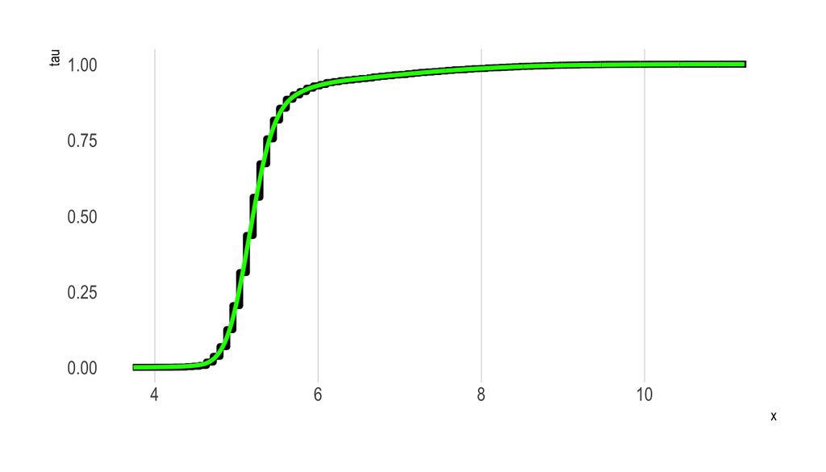

Empirical CDF based on Shape Constrained Additive Model

# Estimating PDFs

Before discussing how to calculate conditional CDFs let’s first cover the basics of estimating and plotting PDFs. Again, R has excellent internal functions to do this. This function (`density()`) uses kernel density estimates of the PDF, with several options for the kernel density method used:

Smoothing Kernels

| Option |
| --- |
| gaussian |
| epanechnikov |
| rectangular |
| triangular |
| biweight |
| cosine |
| optcosine |

Let’s use each to construct a PDF for $Y$.

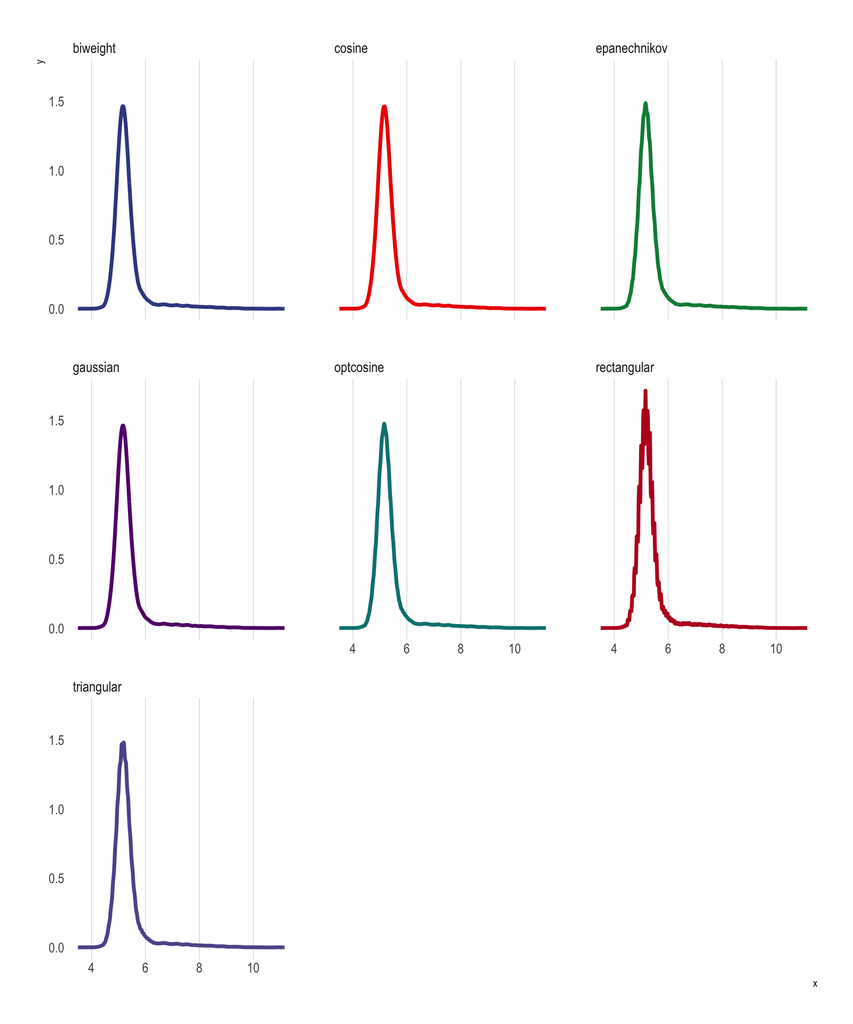

## Do it “By Hand”

We can also leverage Equation 2 and the shape-constrained GAM model fit to construct an estimate of the CDF above to construct the PDF by hand. In the code below, `f0()` is the constructed CDF function, and we can simply add the option `,1` to obtain the first derivative (i.e., `f0(y0)` provides CDF values and `f0(y0,1)` provides PDF values).

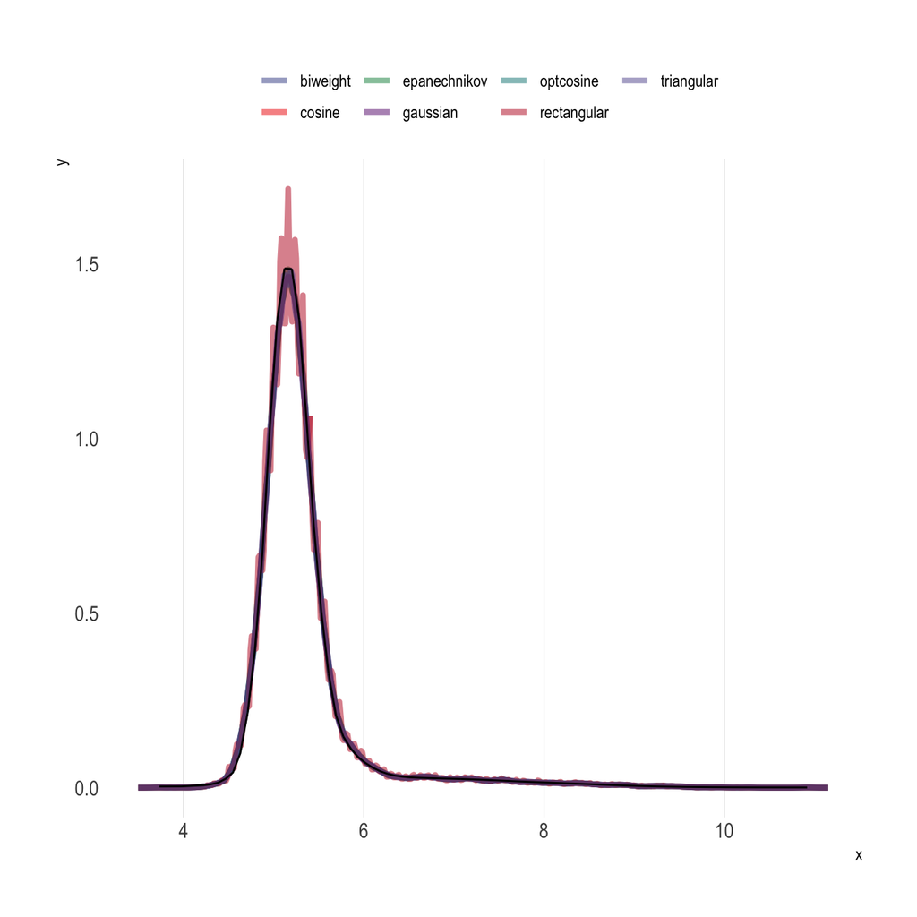

# Average Treatment Effect

We can now use Equation 4 to calculate the an estimate of the expected value of $Y_0$:

First let’s check the mean the usual way:

```
[1] 5.3303
```

We can now find 1,000 points along the support of $Y$ and numerically integrate over the distribution of $Y_0$:

```
[1] 5.3302
```

```
[1] 0.0066533
```

# Conditional CDFs and PDFs

## Conditional CDFs Using Logistic Regression

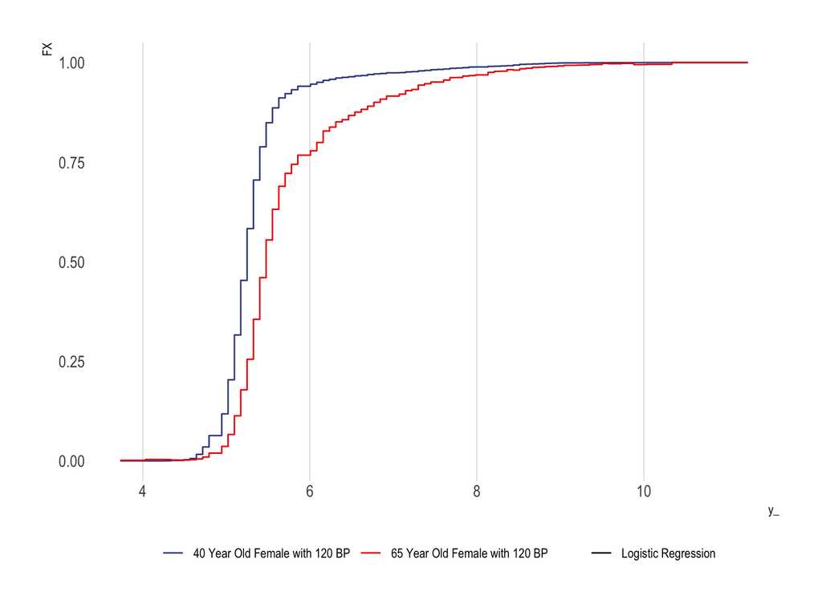

Conditional CDFs Using Logistic Regression

## Conditional CDFs Using Quantile Regression

An alternative method is to use quantile regression

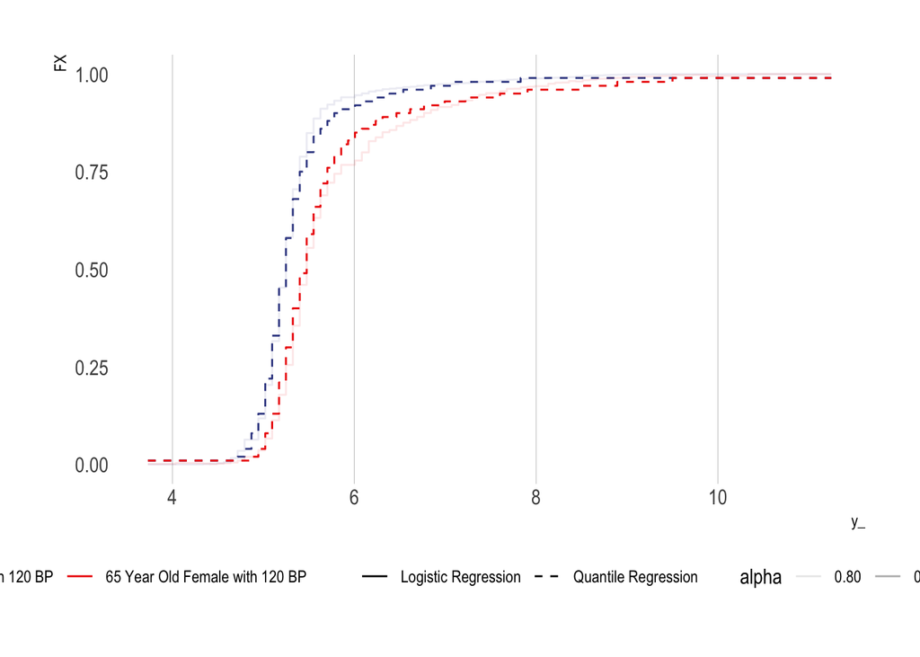

CDFs Constructed Using Quantile Regression

## Conditional CDFs Using Quantile Regression Forests

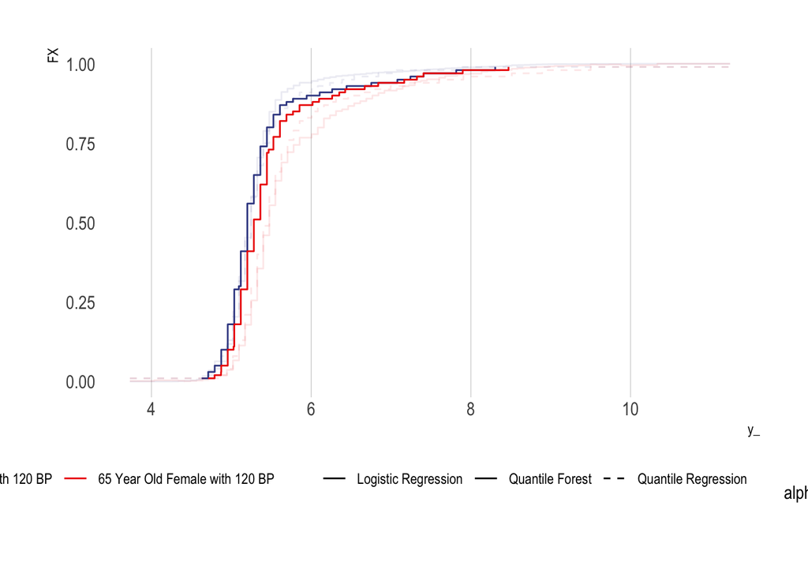

CDFs Constructed Using Quantile Regression Forest